# Risk Factor Analysis

## Outcome Variable

**Outcome Variable:** ever_stunted

## Predictor Variables

**Intervention Variable:** anywast06

**Adjustment Set:**

- arm
- brthmon
- W_mage
- meducyrs
- hhwealth_quart
- month
- W_parity
- delta_W_mage
- delta_meducyrs
- delta_hhwealth_quart
- delta_month
- delta_W_parity

## Stratifying Variables

The analysis was stratified on these variable(s):

- agecat
- studyid
- country

## Data Summary

| agecat | studyid | country | anywast06 | ever_stunted | n_cell | n |
| --- | --- | --- | --- | --- | --- | --- |
| 0-24 months (no birth st.) | CMC-V-BCS-2002 | INDIA | 0 | 0 | 19 | 292 |
| 0-24 months (no birth st.) | CMC-V-BCS-2002 | INDIA | 0 | 1 | 120 | 292 |
| 0-24 months (no birth st.) | CMC-V-BCS-2002 | INDIA | 1 | 0 | 8 | 292 |
| 0-24 months (no birth st.) | CMC-V-BCS-2002 | INDIA | 1 | 1 | 145 | 292 |
| 0-24 months (no birth st.) | CMIN | BANGLADESH | 0 | 0 | 32 | 168 |
| 0-24 months (no birth st.) | CMIN | BANGLADESH | 0 | 1 | 105 | 168 |
| 0-24 months (no birth st.) | CMIN | BANGLADESH | 1 | 0 | 9 | 168 |
| 0-24 months (no birth st.) | CMIN | BANGLADESH | 1 | 1 | 22 | 168 |
| 0-24 months (no birth st.) | CONTENT | PERU | 0 | 0 | 158 | 195 |
| 0-24 months (no birth st.) | CONTENT | PERU | 0 | 1 | 33 | 195 |
| 0-24 months (no birth st.) | CONTENT | PERU | 1 | 0 | 4 | 195 |
| 0-24 months (no birth st.) | CONTENT | PERU | 1 | 1 | 0 | 195 |
| 0-24 months (no birth st.) | EE | PAKISTAN | 0 | 0 | 30 | 213 |
| 0-24 months (no birth st.) | EE | PAKISTAN | 0 | 1 | 105 | 213 |
| 0-24 months (no birth st.) | EE | PAKISTAN | 1 | 0 | 11 | 213 |
| 0-24 months (no birth st.) | EE | PAKISTAN | 1 | 1 | 67 | 213 |
| 0-24 months (no birth st.) | GMS-Nepal | NEPAL | 0 | 0 | 162 | 576 |
| 0-24 months (no birth st.) | GMS-Nepal | NEPAL | 0 | 1 | 179 | 576 |
| 0-24 months (no birth st.) | GMS-Nepal | NEPAL | 1 | 0 | 90 | 576 |
| 0-24 months (no birth st.) | GMS-Nepal | NEPAL | 1 | 1 | 145 | 576 |
| 0-24 months (no birth st.) | Guatemala BSC | GUATEMALA | 0 | 0 | 137 | 223 |
| 0-24 months (no birth st.) | Guatemala BSC | GUATEMALA | 0 | 1 | 82 | 223 |
| 0-24 months (no birth st.) | Guatemala BSC | GUATEMALA | 1 | 0 | 1 | 223 |
| 0-24 months (no birth st.) | Guatemala BSC | GUATEMALA | 1 | 1 | 3 | 223 |
| 0-24 months (no birth st.) | IRC | INDIA | 0 | 0 | 52 | 360 |
| 0-24 months (no birth st.) | IRC | INDIA | 0 | 1 | 100 | 360 |
| 0-24 months (no birth st.) | IRC | INDIA | 1 | 0 | 95 | 360 |
| 0-24 months (no birth st.) | IRC | INDIA | 1 | 1 | 113 | 360 |
| 0-24 months (no birth st.) | Keneba | GAMBIA | 0 | 0 | 823 | 2234 |
| 0-24 months (no birth st.) | Keneba | GAMBIA | 0 | 1 | 755 | 2234 |

[output cut: 186 more lines]

The following strata were considered:

- agecat: 0-24 months (no birth st.), studyid: CMC-V-BCS-2002, country: INDIA
- agecat: 0-24 months (no birth st.), studyid: CMIN, country: BANGLADESH
- agecat: 0-24 months (no birth st.), studyid: CONTENT, country: PERU
- agecat: 0-24 months (no birth st.), studyid: EE, country: PAKISTAN
- agecat: 0-24 months (no birth st.), studyid: GMS-Nepal, country: NEPAL
- agecat: 0-24 months (no birth st.), studyid: Guatemala BSC, country: GUATEMALA
- agecat: 0-24 months (no birth st.), studyid: IRC, country: INDIA
- agecat: 0-24 months (no birth st.), studyid: Keneba, country: GAMBIA
- agecat: 0-24 months (no birth st.), studyid: MAL-ED, country: BANGLADESH
- agecat: 0-24 months (no birth st.), studyid: MAL-ED, country: BRAZIL
- agecat: 0-24 months (no birth st.), studyid: MAL-ED, country: INDIA
- agecat: 0-24 months (no birth st.), studyid: MAL-ED, country: NEPAL
- agecat: 0-24 months (no birth st.), studyid: MAL-ED, country: PERU
- agecat: 0-24 months (no birth st.), studyid: MAL-ED, country: SOUTH AFRICA
- agecat: 0-24 months (no birth st.), studyid: MAL-ED, country: TANZANIA, UNITED REPUBLIC OF
- agecat: 0-24 months (no birth st.), studyid: PROVIDE, country: BANGLADESH
- agecat: 0-24 months (no birth st.), studyid: ResPak, country: PAKISTAN
- agecat: 0-24 months (no birth st.), studyid: TanzaniaChild2, country: TANZANIA, UNITED REPUBLIC OF
- agecat: 0-6 months (no birth st.), studyid: CMC-V-BCS-2002, country: INDIA
- agecat: 0-6 months (no birth st.), studyid: CMIN, country: BANGLADESH
- agecat: 0-6 months (no birth st.), studyid: CONTENT, country: PERU
- agecat: 0-6 months (no birth st.), studyid: EE, country: PAKISTAN
- agecat: 0-6 months (no birth st.), studyid: GMS-Nepal, country: NEPAL
- agecat: 0-6 months (no birth st.), studyid: Guatemala BSC, country: GUATEMALA
- agecat: 0-6 months (no birth st.), studyid: IRC, country: INDIA
- agecat: 0-6 months (no birth st.), studyid: Keneba, country: GAMBIA
- agecat: 0-6 months (no birth st.), studyid: MAL-ED, country: BANGLADESH
- agecat: 0-6 months (no birth st.), studyid: MAL-ED, country: BRAZIL
- agecat: 0-6 months (no birth st.), studyid: MAL-ED, country: INDIA
- agecat: 0-6 months (no birth st.), studyid: MAL-ED, country: NEPAL
- agecat: 0-6 months (no birth st.), studyid: MAL-ED, country: PERU
- agecat: 0-6 months (no birth st.), studyid: MAL-ED, country: SOUTH AFRICA
- agecat: 0-6 months (no birth st.), studyid: MAL-ED, country: TANZANIA, UNITED REPUBLIC OF
- agecat: 0-6 months (no birth st.), studyid: PROVIDE, country: BANGLADESH
- agecat: 0-6 months (no birth st.), studyid: ResPak, country: PAKISTAN
- agecat: 0-6 months (no birth st.), studyid: TanzaniaChild2, country: TANZANIA, UNITED REPUBLIC OF
- agecat: 6-24 months, studyid: CMC-V-BCS-2002, country: INDIA
- agecat: 6-24 months, studyid: CMIN, country: BANGLADESH
- agecat: 6-24 months, studyid: CONTENT, country: PERU
- agecat: 6-24 months, studyid: EE, country: PAKISTAN
- agecat: 6-24 months, studyid: GMS-Nepal, country: NEPAL
- agecat: 6-24 months, studyid: Guatemala BSC, country: GUATEMALA
- agecat: 6-24 months, studyid: IRC, country: INDIA
- agecat: 6-24 months, studyid: Keneba, country: GAMBIA
- agecat: 6-24 months, studyid: MAL-ED, country: BANGLADESH
- agecat: 6-24 months, studyid: MAL-ED, country: BRAZIL
- agecat: 6-24 months, studyid: MAL-ED, country: INDIA
- agecat: 6-24 months, studyid: MAL-ED, country: NEPAL
- agecat: 6-24 months, studyid: MAL-ED, country: PERU
- agecat: 6-24 months, studyid: MAL-ED, country: SOUTH AFRICA
- agecat: 6-24 months, studyid: MAL-ED, country: TANZANIA, UNITED REPUBLIC OF
- agecat: 6-24 months, studyid: PROVIDE, country: BANGLADESH
- agecat: 6-24 months, studyid: ResPak, country: PAKISTAN
- agecat: 6-24 months, studyid: TanzaniaChild2, country: TANZANIA, UNITED REPUBLIC OF

### Dropped Strata

Some strata were dropped due to rare outcomes:

- agecat: 0-24 months (no birth st.), studyid: CONTENT, country: PERU
- agecat: 0-24 months (no birth st.), studyid: Guatemala BSC, country: GUATEMALA
- agecat: 0-24 months (no birth st.), studyid: MAL-ED, country: BRAZIL
- agecat: 0-24 months (no birth st.), studyid: MAL-ED, country: PERU
- agecat: 0-24 months (no birth st.), studyid: MAL-ED, country: TANZANIA, UNITED REPUBLIC OF
- agecat: 0-6 months (no birth st.), studyid: CONTENT, country: PERU
- agecat: 0-6 months (no birth st.), studyid: Guatemala BSC, country: GUATEMALA
- agecat: 0-6 months (no birth st.), studyid: MAL-ED, country: BRAZIL
- agecat: 0-6 months (no birth st.), studyid: MAL-ED, country: NEPAL
- agecat: 0-6 months (no birth st.), studyid: MAL-ED, country: PERU
- agecat: 0-6 months (no birth st.), studyid: MAL-ED, country: TANZANIA, UNITED REPUBLIC OF
- agecat: 6-24 months, studyid: CONTENT, country: PERU
- agecat: 6-24 months, studyid: Guatemala BSC, country: GUATEMALA
- agecat: 6-24 months, studyid: MAL-ED, country: BRAZIL
- agecat: 6-24 months, studyid: MAL-ED, country: PERU
- agecat: 6-24 months, studyid: MAL-ED, country: TANZANIA, UNITED REPUBLIC OF

## Methods Detail

We’re interested in the causal parameters $E[Y_a]$ for all values of $a \in \mathcal{A}$. These parameters represent the mean outcome if, possibly contrary to fact, we intervened to set all units to have $A=a$. Under the randomization and positivity assumptions, these are identified by the statistical parameters $\psi_a=E_W[E_{Y|A,W}(Y|A=a,W)]$. In addition, we’re interested in the mean of $Y$, $E[Y]$ under no intervention (the observed mean). We will estimate these parameters by using SuperLearner to fit the relevant likelihood factors – $E_{Y|A,W}(Y|A=a,W)$ and $p(A=a|W)$, and then updating our likelihood fit using a joint TMLE.

For unadjusted analyses ($W=\{\}$), initial likelihoods were estimated using Lrnr_glm to estimate the simple $E(Y|A)$ and Lrnr_mean to estimate $p(A)$. For adjusted analyses, a small library containing Lrnr_glmnet, Lrnr_xgboost, and Lrnr_mean was used.

Having estimated these parameters, we will then use the delta method to estimate relative risks and attributable risks relative to a prespecified baseline level of $A$.

# Results Detail

## Results Plots

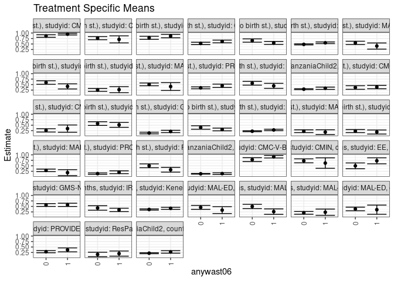

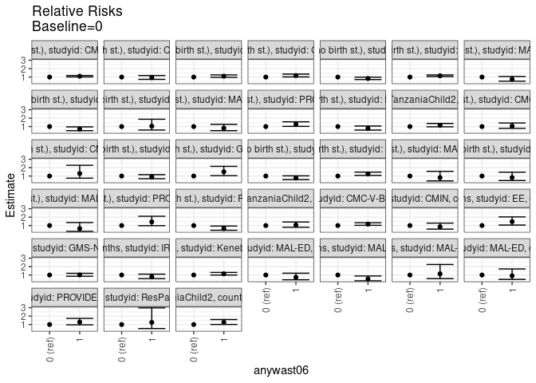

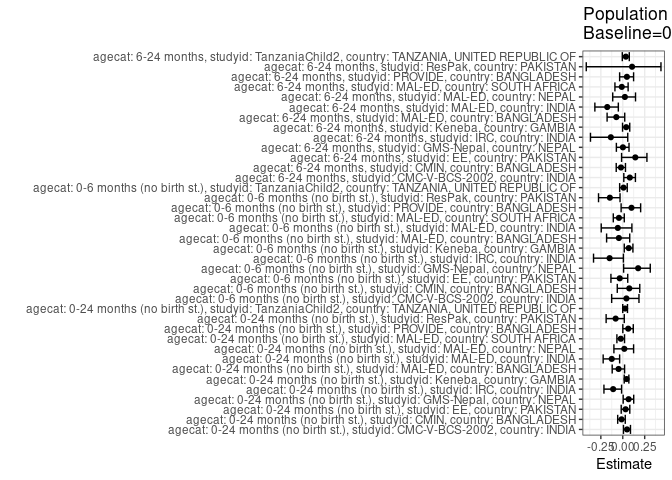

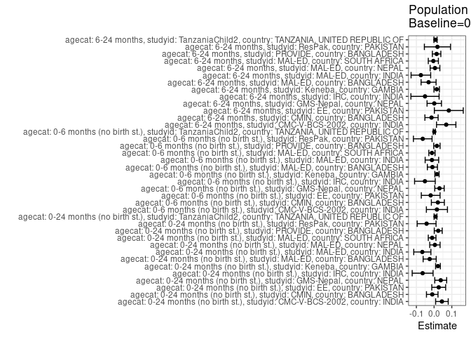

## Results Table

### Parameter: TSM

| agecat | studyid | country | intervention_level | baseline_level | estimate | ci_lower | ci_upper |
| --- | --- | --- | --- | --- | --- | --- | --- |
| 0-24 months (no birth st.) | CMC-V-BCS-2002 | INDIA | 0 | NA | 0.8633094 | 0.8061038 | 0.9205149 |
| 0-24 months (no birth st.) | CMC-V-BCS-2002 | INDIA | 1 | NA | 0.9477124 | 0.9123791 | 0.9830458 |
| 0-24 months (no birth st.) | CMIN | BANGLADESH | 0 | NA | 0.7664234 | 0.6953620 | 0.8374847 |
| 0-24 months (no birth st.) | CMIN | BANGLADESH | 1 | NA | 0.7096774 | 0.5494139 | 0.8699409 |
| 0-24 months (no birth st.) | EE | PAKISTAN | 0 | NA | 0.7813695 | 0.7106190 | 0.8521201 |
| 0-24 months (no birth st.) | EE | PAKISTAN | 1 | NA | 0.8617204 | 0.7828792 | 0.9405617 |
| 0-24 months (no birth st.) | GMS-Nepal | NEPAL | 0 | NA | 0.5249892 | 0.4716892 | 0.5782891 |
| 0-24 months (no birth st.) | GMS-Nepal | NEPAL | 1 | NA | 0.6155440 | 0.5539937 | 0.6770944 |
| 0-24 months (no birth st.) | IRC | INDIA | 0 | NA | 0.6564229 | 0.5805686 | 0.7322773 |
| 0-24 months (no birth st.) | IRC | INDIA | 1 | NA | 0.5478681 | 0.4800125 | 0.6157238 |
| 0-24 months (no birth st.) | Keneba | GAMBIA | 0 | NA | 0.4825634 | 0.4579494 | 0.5071773 |
| 0-24 months (no birth st.) | Keneba | GAMBIA | 1 | NA | 0.5547018 | 0.5168199 | 0.5925838 |
| 0-24 months (no birth st.) | MAL-ED | BANGLADESH | 0 | NA | 0.5503423 | 0.4746583 | 0.6260262 |
| 0-24 months (no birth st.) | MAL-ED | BANGLADESH | 1 | NA | 0.4059724 | 0.2655801 | 0.5463647 |
| 0-24 months (no birth st.) | MAL-ED | INDIA | 0 | NA | 0.5950413 | 0.5139283 | 0.6761544 |
| 0-24 months (no birth st.) | MAL-ED | INDIA | 1 | NA | 0.4180979 | 0.3000910 | 0.5361048 |
| 0-24 months (no birth st.) | MAL-ED | NEPAL | 0 | NA | 0.2560720 | 0.1907075 | 0.3214365 |
| 0-24 months (no birth st.) | MAL-ED | NEPAL | 1 | NA | 0.2685279 | 0.1296390 | 0.4074168 |
| 0-24 months (no birth st.) | MAL-ED | SOUTH AFRICA | 0 | NA | 0.5093540 | 0.4462742 | 0.5724338 |
| 0-24 months (no birth st.) | MAL-ED | SOUTH AFRICA | 1 | NA | 0.4109452 | 0.2331935 | 0.5886969 |
| 0-24 months (no birth st.) | PROVIDE | BANGLADESH | 0 | NA | 0.3526058 | 0.3095130 | 0.3956986 |
| 0-24 months (no birth st.) | PROVIDE | BANGLADESH | 1 | NA | 0.4461759 | 0.3690017 | 0.5233501 |
| 0-24 months (no birth st.) | ResPak | PAKISTAN | 0 | NA | 0.5620922 | 0.4754507 | 0.6487338 |
| 0-24 months (no birth st.) | ResPak | PAKISTAN | 1 | NA | 0.4423259 | 0.3279011 | 0.5567508 |
| 0-24 months (no birth st.) | TanzaniaChild2 | TANZANIA, UNITED REPUBLIC OF | 0 | NA | 0.2907932 | 0.2704400 | 0.3111465 |
| 0-24 months (no birth st.) | TanzaniaChild2 | TANZANIA, UNITED REPUBLIC OF | 1 | NA | 0.3348858 | 0.2826937 | 0.3870779 |
| 0-6 months (no birth st.) | CMC-V-BCS-2002 | INDIA | 0 | NA | 0.3676033 | 0.2866298 | 0.4485769 |
| 0-6 months (no birth st.) | CMC-V-BCS-2002 | INDIA | 1 | NA | 0.3880654 | 0.3105733 | 0.4655576 |
| 0-6 months (no birth st.) | CMIN | BANGLADESH | 0 | NA | 0.2644475 | 0.1898132 | 0.3390818 |
| 0-6 months (no birth st.) | CMIN | BANGLADESH | 1 | NA | 0.3445448 | 0.1794621 | 0.5096274 |
| 0-6 months (no birth st.) | EE | PAKISTAN | 0 | NA | 0.5732793 | 0.4882539 | 0.6583047 |
| 0-6 months (no birth st.) | EE | PAKISTAN | 1 | NA | 0.5138302 | 0.4026831 | 0.6249773 |
| 0-6 months (no birth st.) | GMS-Nepal | NEPAL | 0 | NA | 0.1431496 | 0.1058153 | 0.1804838 |
| 0-6 months (no birth st.) | GMS-Nepal | NEPAL | 1 | NA | 0.2154156 | 0.1623748 | 0.2684564 |
| 0-6 months (no birth st.) | IRC | INDIA | 0 | NA | 0.3962203 | 0.3179733 | 0.4744673 |
| 0-6 months (no birth st.) | IRC | INDIA | 1 | NA | 0.3053932 | 0.2424077 | 0.3683787 |
| 0-6 months (no birth st.) | Keneba | GAMBIA | 0 | NA | 0.2249378 | 0.2042561 | 0.2456195 |
| 0-6 months (no birth st.) | Keneba | GAMBIA | 1 | NA | 0.2830461 | 0.2483995 | 0.3176927 |
| 0-6 months (no birth st.) | MAL-ED | BANGLADESH | 0 | NA | 0.2261905 | 0.1627815 | 0.2895994 |
| 0-6 months (no birth st.) | MAL-ED | BANGLADESH | 1 | NA | 0.1836735 | 0.0750038 | 0.2923431 |
| 0-6 months (no birth st.) | MAL-ED | INDIA | 0 | NA | 0.2313943 | 0.1620839 | 0.3007047 |
| 0-6 months (no birth st.) | MAL-ED | INDIA | 1 | NA | 0.1896218 | 0.0971639 | 0.2820797 |
| 0-6 months (no birth st.) | MAL-ED | SOUTH AFRICA | 0 | NA | 0.2921811 | 0.2348984 | 0.3494637 |
| 0-6 months (no birth st.) | MAL-ED | SOUTH AFRICA | 1 | NA | 0.1875000 | 0.0520196 | 0.3229804 |
| 0-6 months (no birth st.) | PROVIDE | BANGLADESH | 0 | NA | 0.1437089 | 0.1121064 | 0.1753113 |
| 0-6 months (no birth st.) | PROVIDE | BANGLADESH | 1 | NA | 0.2065256 | 0.1422416 | 0.2708096 |
| 0-6 months (no birth st.) | ResPak | PAKISTAN | 0 | NA | 0.4997622 | 0.4121192 | 0.5874052 |
| 0-6 months (no birth st.) | ResPak | PAKISTAN | 1 | NA | 0.3207289 | 0.2119410 | 0.4295168 |
| 0-6 months (no birth st.) | TanzaniaChild2 | TANZANIA, UNITED REPUBLIC OF | 0 | NA | 0.1357236 | 0.1203831 | 0.1510641 |
| 0-6 months (no birth st.) | TanzaniaChild2 | TANZANIA, UNITED REPUBLIC OF | 1 | NA | 0.1440264 | 0.1052658 | 0.1827871 |
| 6-24 months | CMC-V-BCS-2002 | INDIA | 0 | NA | 0.7816092 | 0.6945509 | 0.8686675 |
| 6-24 months | CMC-V-BCS-2002 | INDIA | 1 | NA | 0.9139785 | 0.8568322 | 0.9711248 |
| 6-24 months | CMIN | BANGLADESH | 0 | NA | 0.7263158 | 0.6362543 | 0.8163773 |
| 6-24 months | CMIN | BANGLADESH | 1 | NA | 0.6250000 | 0.3867083 | 0.8632917 |
| 6-24 months | EE | PAKISTAN | 0 | NA | 0.4975435 | 0.3651361 | 0.6299509 |
| 6-24 months | EE | PAKISTAN | 1 | NA | 0.7273764 | 0.5905519 | 0.8642010 |
| 6-24 months | GMS-Nepal | NEPAL | 0 | NA | 0.5632652 | 0.4988548 | 0.6276756 |
| 6-24 months | GMS-Nepal | NEPAL | 1 | NA | 0.5708259 | 0.4963204 | 0.6453314 |
| 6-24 months | IRC | INDIA | 0 | NA | 0.4284313 | 0.3255561 | 0.5313066 |
| 6-24 months | IRC | INDIA | 1 | NA | 0.3412827 | 0.2635608 | 0.4190047 |
| 6-24 months | Keneba | GAMBIA | 0 | NA | 0.3604817 | 0.3323039 | 0.3886595 |
| 6-24 months | Keneba | GAMBIA | 1 | NA | 0.4119682 | 0.3661515 | 0.4577850 |
| 6-24 months | MAL-ED | BANGLADESH | 0 | NA | 0.4551959 | 0.3658413 | 0.5445504 |
| 6-24 months | MAL-ED | BANGLADESH | 1 | NA | 0.3316007 | 0.1750854 | 0.4881160 |
| 6-24 months | MAL-ED | INDIA | 0 | NA | 0.4967103 | 0.3986060 | 0.5948147 |
| 6-24 months | MAL-ED | INDIA | 1 | NA | 0.2627382 | 0.1379678 | 0.3875085 |
| 6-24 months | MAL-ED | NEPAL | 0 | NA | 0.2062500 | 0.1433937 | 0.2691063 |
| 6-24 months | MAL-ED | NEPAL | 1 | NA | 0.2352941 | 0.0923443 | 0.3782439 |
| 6-24 months | MAL-ED | SOUTH AFRICA | 0 | NA | 0.3840580 | 0.3026521 | 0.4654638 |
| 6-24 months | MAL-ED | SOUTH AFRICA | 1 | NA | 0.3500000 | 0.1402980 | 0.5597020 |
| 6-24 months | PROVIDE | BANGLADESH | 0 | NA | 0.2862736 | 0.2388655 | 0.3336818 |
| 6-24 months | PROVIDE | BANGLADESH | 1 | NA | 0.3689046 | 0.2798264 | 0.4579827 |
| 6-24 months | ResPak | PAKISTAN | 0 | NA | 0.1600000 | 0.0578448 | 0.2621552 |
| 6-24 months | ResPak | PAKISTAN | 1 | NA | 0.2000000 | 0.0825103 | 0.3174897 |
| 6-24 months | TanzaniaChild2 | TANZANIA, UNITED REPUBLIC OF | 0 | NA | 0.2179972 | 0.1960807 | 0.2399137 |
| 6-24 months | TanzaniaChild2 | TANZANIA, UNITED REPUBLIC OF | 1 | NA | 0.2758753 | 0.2192670 | 0.3324835 |

### Parameter: E(Y)

| agecat | studyid | country | intervention_level | baseline_level | estimate | ci_lower | ci_upper |
| --- | --- | --- | --- | --- | --- | --- | --- |
| 0-24 months (no birth st.) | CMC-V-BCS-2002 | INDIA | NA | NA | 0.9075342 | 0.8742512 | 0.9408173 |
| 0-24 months (no birth st.) | CMIN | BANGLADESH | NA | NA | 0.7559524 | 0.6908084 | 0.8210964 |
| 0-24 months (no birth st.) | EE | PAKISTAN | NA | NA | 0.8075117 | 0.7544408 | 0.8605827 |
| 0-24 months (no birth st.) | GMS-Nepal | NEPAL | NA | NA | 0.5625000 | 0.5219525 | 0.6030475 |
| 0-24 months (no birth st.) | IRC | INDIA | NA | NA | 0.5916667 | 0.5408218 | 0.6425115 |
| 0-24 months (no birth st.) | Keneba | GAMBIA | NA | NA | 0.5044763 | 0.4837388 | 0.5252138 |
| 0-24 months (no birth st.) | MAL-ED | BANGLADESH | NA | NA | 0.5253456 | 0.4587520 | 0.5919392 |
| 0-24 months (no birth st.) | MAL-ED | INDIA | NA | NA | 0.5285714 | 0.4608954 | 0.5962474 |
| 0-24 months (no birth st.) | MAL-ED | NEPAL | NA | NA | 0.2606635 | 0.2012891 | 0.3200380 |
| 0-24 months (no birth st.) | MAL-ED | SOUTH AFRICA | NA | NA | 0.4981818 | 0.4389793 | 0.5573843 |
| 0-24 months (no birth st.) | PROVIDE | BANGLADESH | NA | NA | 0.3759874 | 0.3382238 | 0.4137509 |
| 0-24 months (no birth st.) | ResPak | PAKISTAN | NA | NA | 0.5198020 | 0.4507336 | 0.5888704 |
| 0-24 months (no birth st.) | TanzaniaChild2 | TANZANIA, UNITED REPUBLIC OF | NA | NA | 0.2988814 | 0.2798990 | 0.3178639 |
| 0-6 months (no birth st.) | CMC-V-BCS-2002 | INDIA | NA | NA | 0.3835616 | 0.3276935 | 0.4394298 |
| 0-6 months (no birth st.) | CMIN | BANGLADESH | NA | NA | 0.2857143 | 0.2171983 | 0.3542303 |
| 0-6 months (no birth st.) | EE | PAKISTAN | NA | NA | 0.5539906 | 0.4870787 | 0.6209025 |
| 0-6 months (no birth st.) | GMS-Nepal | NEPAL | NA | NA | 0.1736111 | 0.1426515 | 0.2045707 |
| 0-6 months (no birth st.) | IRC | INDIA | NA | NA | 0.3444444 | 0.2952897 | 0.3935992 |
| 0-6 months (no birth st.) | Keneba | GAMBIA | NA | NA | 0.2412713 | 0.2235253 | 0.2590172 |
| 0-6 months (no birth st.) | MAL-ED | BANGLADESH | NA | NA | 0.2165899 | 0.1616567 | 0.2715231 |
| 0-6 months (no birth st.) | MAL-ED | INDIA | NA | NA | 0.2190476 | 0.1629743 | 0.2751210 |
| 0-6 months (no birth st.) | MAL-ED | SOUTH AFRICA | NA | NA | 0.2800000 | 0.2268359 | 0.3331641 |
| 0-6 months (no birth st.) | PROVIDE | BANGLADESH | NA | NA | 0.1595577 | 0.1310079 | 0.1881074 |
| 0-6 months (no birth st.) | ResPak | PAKISTAN | NA | NA | 0.4356436 | 0.3670959 | 0.5041912 |
| 0-6 months (no birth st.) | TanzaniaChild2 | TANZANIA, UNITED REPUBLIC OF | NA | NA | 0.1369128 | 0.1226581 | 0.1511674 |
| 6-24 months | CMC-V-BCS-2002 | INDIA | NA | NA | 0.8500000 | 0.7976910 | 0.9023090 |
| 6-24 months | CMIN | BANGLADESH | NA | NA | 0.7117117 | 0.6270636 | 0.7963598 |
| 6-24 months | EE | PAKISTAN | NA | NA | 0.5806452 | 0.4798127 | 0.6814776 |
| 6-24 months | GMS-Nepal | NEPAL | NA | NA | 0.5642317 | 0.5153938 | 0.6130696 |
| 6-24 months | IRC | INDIA | NA | NA | 0.3771186 | 0.3151523 | 0.4390850 |
| 6-24 months | Keneba | GAMBIA | NA | NA | 0.3752393 | 0.3512585 | 0.3992201 |
| 6-24 months | MAL-ED | BANGLADESH | NA | NA | 0.4240506 | 0.3467471 | 0.5013542 |
| 6-24 months | MAL-ED | INDIA | NA | NA | 0.4220779 | 0.3438191 | 0.5003368 |
| 6-24 months | MAL-ED | NEPAL | NA | NA | 0.2113402 | 0.1537425 | 0.2689379 |
| 6-24 months | MAL-ED | SOUTH AFRICA | NA | NA | 0.3797468 | 0.3038314 | 0.4556622 |
| 6-24 months | PROVIDE | BANGLADESH | NA | NA | 0.3004386 | 0.2583143 | 0.3425629 |
| 6-24 months | ResPak | PAKISTAN | NA | NA | 0.1789474 | 0.1014597 | 0.2564350 |
| 6-24 months | TanzaniaChild2 | TANZANIA, UNITED REPUBLIC OF | NA | NA | 0.2259675 | 0.2054816 | 0.2464534 |

### Parameter: RR

| agecat | studyid | country | intervention_level | baseline_level | estimate | ci_lower | ci_upper |
| --- | --- | --- | --- | --- | --- | --- | --- |
| 0-24 months (no birth st.) | CMC-V-BCS-2002 | INDIA | 0 | 0 | 1.0000000 | 1.0000000 | 1.0000000 |
| 0-24 months (no birth st.) | CMC-V-BCS-2002 | INDIA | 1 | 0 | 1.0977669 | 1.0173960 | 1.1844868 |
| 0-24 months (no birth st.) | CMIN | BANGLADESH | 0 | 0 | 1.0000000 | 1.0000000 | 1.0000000 |
| 0-24 months (no birth st.) | CMIN | BANGLADESH | 1 | 0 | 0.9259601 | 0.7253921 | 1.1819842 |
| 0-24 months (no birth st.) | EE | PAKISTAN | 0 | 0 | 1.0000000 | 1.0000000 | 1.0000000 |
| 0-24 months (no birth st.) | EE | PAKISTAN | 1 | 0 | 1.1028334 | 0.9692700 | 1.2548017 |
| 0-24 months (no birth st.) | GMS-Nepal | NEPAL | 0 | 0 | 1.0000000 | 1.0000000 | 1.0000000 |
| 0-24 months (no birth st.) | GMS-Nepal | NEPAL | 1 | 0 | 1.1724890 | 1.0168435 | 1.3519588 |
| 0-24 months (no birth st.) | IRC | INDIA | 0 | 0 | 1.0000000 | 1.0000000 | 1.0000000 |
| 0-24 months (no birth st.) | IRC | INDIA | 1 | 0 | 0.8346267 | 0.7050889 | 0.9879631 |
| 0-24 months (no birth st.) | Keneba | GAMBIA | 0 | 0 | 1.0000000 | 1.0000000 | 1.0000000 |
| 0-24 months (no birth st.) | Keneba | GAMBIA | 1 | 0 | 1.1494901 | 1.0560493 | 1.2511988 |
| 0-24 months (no birth st.) | MAL-ED | BANGLADESH | 0 | 0 | 1.0000000 | 1.0000000 | 1.0000000 |
| 0-24 months (no birth st.) | MAL-ED | BANGLADESH | 1 | 0 | 0.7376725 | 0.5079535 | 1.0712806 |
| 0-24 months (no birth st.) | MAL-ED | INDIA | 0 | 0 | 1.0000000 | 1.0000000 | 1.0000000 |
| 0-24 months (no birth st.) | MAL-ED | INDIA | 1 | 0 | 0.7026368 | 0.5127536 | 0.9628376 |
| 0-24 months (no birth st.) | MAL-ED | NEPAL | 0 | 0 | 1.0000000 | 1.0000000 | 1.0000000 |
| 0-24 months (no birth st.) | MAL-ED | NEPAL | 1 | 0 | 1.0486423 | 0.5886213 | 1.8681803 |
| 0-24 months (no birth st.) | MAL-ED | SOUTH AFRICA | 0 | 0 | 1.0000000 | 1.0000000 | 1.0000000 |
| 0-24 months (no birth st.) | MAL-ED | SOUTH AFRICA | 1 | 0 | 0.8067969 | 0.5142667 | 1.2657270 |
| 0-24 months (no birth st.) | PROVIDE | BANGLADESH | 0 | 0 | 1.0000000 | 1.0000000 | 1.0000000 |
| 0-24 months (no birth st.) | PROVIDE | BANGLADESH | 1 | 0 | 1.2653675 | 1.0242167 | 1.5632969 |
| 0-24 months (no birth st.) | ResPak | PAKISTAN | 0 | 0 | 1.0000000 | 1.0000000 | 1.0000000 |
| 0-24 months (no birth st.) | ResPak | PAKISTAN | 1 | 0 | 0.7869277 | 0.5825305 | 1.0630434 |
| 0-24 months (no birth st.) | TanzaniaChild2 | TANZANIA, UNITED REPUBLIC OF | 0 | 0 | 1.0000000 | 1.0000000 | 1.0000000 |
| 0-24 months (no birth st.) | TanzaniaChild2 | TANZANIA, UNITED REPUBLIC OF | 1 | 0 | 1.1516285 | 0.9707485 | 1.3662121 |
| 0-6 months (no birth st.) | CMC-V-BCS-2002 | INDIA | 0 | 0 | 1.0000000 | 1.0000000 | 1.0000000 |
| 0-6 months (no birth st.) | CMC-V-BCS-2002 | INDIA | 1 | 0 | 1.0556635 | 0.7833839 | 1.4225791 |
| 0-6 months (no birth st.) | CMIN | BANGLADESH | 0 | 0 | 1.0000000 | 1.0000000 | 1.0000000 |
| 0-6 months (no birth st.) | CMIN | BANGLADESH | 1 | 0 | 1.3028854 | 0.7462108 | 2.2748402 |
| 0-6 months (no birth st.) | EE | PAKISTAN | 0 | 0 | 1.0000000 | 1.0000000 | 1.0000000 |
| 0-6 months (no birth st.) | EE | PAKISTAN | 1 | 0 | 0.8962998 | 0.6887971 | 1.1663136 |
| 0-6 months (no birth st.) | GMS-Nepal | NEPAL | 0 | 0 | 1.0000000 | 1.0000000 | 1.0000000 |
| 0-6 months (no birth st.) | GMS-Nepal | NEPAL | 1 | 0 | 1.5048292 | 1.0512238 | 2.1541664 |
| 0-6 months (no birth st.) | IRC | INDIA | 0 | 0 | 1.0000000 | 1.0000000 | 1.0000000 |
| 0-6 months (no birth st.) | IRC | INDIA | 1 | 0 | 0.7707662 | 0.5790646 | 1.0259313 |
| 0-6 months (no birth st.) | Keneba | GAMBIA | 0 | 0 | 1.0000000 | 1.0000000 | 1.0000000 |
| 0-6 months (no birth st.) | Keneba | GAMBIA | 1 | 0 | 1.2583306 | 1.0798142 | 1.4663594 |
| 0-6 months (no birth st.) | MAL-ED | BANGLADESH | 0 | 0 | 1.0000000 | 1.0000000 | 1.0000000 |
| 0-6 months (no birth st.) | MAL-ED | BANGLADESH | 1 | 0 | 0.8120301 | 0.4219291 | 1.5628047 |
| 0-6 months (no birth st.) | MAL-ED | INDIA | 0 | 0 | 1.0000000 | 1.0000000 | 1.0000000 |
| 0-6 months (no birth st.) | MAL-ED | INDIA | 1 | 0 | 0.8194750 | 0.4614114 | 1.4554022 |
| 0-6 months (no birth st.) | MAL-ED | SOUTH AFRICA | 0 | 0 | 1.0000000 | 1.0000000 | 1.0000000 |
| 0-6 months (no birth st.) | MAL-ED | SOUTH AFRICA | 1 | 0 | 0.6417254 | 0.3035278 | 1.3567502 |
| 0-6 months (no birth st.) | PROVIDE | BANGLADESH | 0 | 0 | 1.0000000 | 1.0000000 | 1.0000000 |
| 0-6 months (no birth st.) | PROVIDE | BANGLADESH | 1 | 0 | 1.4371109 | 0.9820009 | 2.1031424 |
| 0-6 months (no birth st.) | ResPak | PAKISTAN | 0 | 0 | 1.0000000 | 1.0000000 | 1.0000000 |
| 0-6 months (no birth st.) | ResPak | PAKISTAN | 1 | 0 | 0.6417630 | 0.4380258 | 0.9402637 |
| 0-6 months (no birth st.) | TanzaniaChild2 | TANZANIA, UNITED REPUBLIC OF | 0 | 0 | 1.0000000 | 1.0000000 | 1.0000000 |
| 0-6 months (no birth st.) | TanzaniaChild2 | TANZANIA, UNITED REPUBLIC OF | 1 | 0 | 1.0611745 | 0.7925979 | 1.4207597 |
| 6-24 months | CMC-V-BCS-2002 | INDIA | 0 | 0 | 1.0000000 | 1.0000000 | 1.0000000 |
| 6-24 months | CMC-V-BCS-2002 | INDIA | 1 | 0 | 1.1693548 | 1.0291360 | 1.3286784 |
| 6-24 months | CMIN | BANGLADESH | 0 | 0 | 1.0000000 | 1.0000000 | 1.0000000 |
| 6-24 months | CMIN | BANGLADESH | 1 | 0 | 0.8605072 | 0.5762828 | 1.2849121 |
| 6-24 months | EE | PAKISTAN | 0 | 0 | 1.0000000 | 1.0000000 | 1.0000000 |
| 6-24 months | EE | PAKISTAN | 1 | 0 | 1.4619354 | 1.0554664 | 2.0249391 |
| 6-24 months | GMS-Nepal | NEPAL | 0 | 0 | 1.0000000 | 1.0000000 | 1.0000000 |
| 6-24 months | GMS-Nepal | NEPAL | 1 | 0 | 1.0134230 | 0.8528825 | 1.2041825 |
| 6-24 months | IRC | INDIA | 0 | 0 | 1.0000000 | 1.0000000 | 1.0000000 |
| 6-24 months | IRC | INDIA | 1 | 0 | 0.7965868 | 0.5733393 | 1.1067627 |
| 6-24 months | Keneba | GAMBIA | 0 | 0 | 1.0000000 | 1.0000000 | 1.0000000 |
| 6-24 months | Keneba | GAMBIA | 1 | 0 | 1.1428270 | 0.9978732 | 1.3088372 |
| 6-24 months | MAL-ED | BANGLADESH | 0 | 0 | 1.0000000 | 1.0000000 | 1.0000000 |
| 6-24 months | MAL-ED | BANGLADESH | 1 | 0 | 0.7284792 | 0.4366808 | 1.2152629 |
| 6-24 months | MAL-ED | INDIA | 0 | 0 | 1.0000000 | 1.0000000 | 1.0000000 |
| 6-24 months | MAL-ED | INDIA | 1 | 0 | 0.5289565 | 0.3167487 | 0.8833342 |
| 6-24 months | MAL-ED | NEPAL | 0 | 0 | 1.0000000 | 1.0000000 | 1.0000000 |
| 6-24 months | MAL-ED | NEPAL | 1 | 0 | 1.1408200 | 0.5781380 | 2.2511409 |
| 6-24 months | MAL-ED | SOUTH AFRICA | 0 | 0 | 1.0000000 | 1.0000000 | 1.0000000 |
| 6-24 months | MAL-ED | SOUTH AFRICA | 1 | 0 | 0.9113208 | 0.4826821 | 1.7206057 |
| 6-24 months | PROVIDE | BANGLADESH | 0 | 0 | 1.0000000 | 1.0000000 | 1.0000000 |
| 6-24 months | PROVIDE | BANGLADESH | 1 | 0 | 1.2886432 | 0.9623627 | 1.7255460 |
| 6-24 months | ResPak | PAKISTAN | 0 | 0 | 1.0000000 | 1.0000000 | 1.0000000 |
| 6-24 months | ResPak | PAKISTAN | 1 | 0 | 1.2500000 | 0.5249448 | 2.9765036 |
| 6-24 months | TanzaniaChild2 | TANZANIA, UNITED REPUBLIC OF | 0 | 0 | 1.0000000 | 1.0000000 | 1.0000000 |
| 6-24 months | TanzaniaChild2 | TANZANIA, UNITED REPUBLIC OF | 1 | 0 | 1.2654991 | 1.0069048 | 1.5905059 |

### Parameter: PAR

| agecat | studyid | country | intervention_level | baseline_level | estimate | ci_lower | ci_upper |
| --- | --- | --- | --- | --- | --- | --- | --- |
| 0-24 months (no birth st.) | CMC-V-BCS-2002 | INDIA | 0 | NA | 0.0442249 | 0.0086628 | 0.0797870 |
| 0-24 months (no birth st.) | CMIN | BANGLADESH | 0 | NA | -0.0104710 | -0.0429919 | 0.0220500 |
| 0-24 months (no birth st.) | EE | PAKISTAN | 0 | NA | 0.0261422 | -0.0130301 | 0.0653145 |
| 0-24 months (no birth st.) | GMS-Nepal | NEPAL | 0 | NA | 0.0375108 | 0.0039407 | 0.0710809 |
| 0-24 months (no birth st.) | IRC | INDIA | 0 | NA | -0.0647563 | -0.1236767 | -0.0058359 |
| 0-24 months (no birth st.) | Keneba | GAMBIA | 0 | NA | 0.0219129 | 0.0086450 | 0.0351808 |
| 0-24 months (no birth st.) | MAL-ED | BANGLADESH | 0 | NA | -0.0249966 | -0.0619099 | 0.0119166 |
| 0-24 months (no birth st.) | MAL-ED | INDIA | 0 | NA | -0.0664699 | -0.1148522 | -0.0180876 |
| 0-24 months (no birth st.) | MAL-ED | NEPAL | 0 | NA | 0.0045915 | -0.0246336 | 0.0338166 |
| 0-24 months (no birth st.) | MAL-ED | SOUTH AFRICA | 0 | NA | -0.0111721 | -0.0328344 | 0.0104901 |
| 0-24 months (no birth st.) | PROVIDE | BANGLADESH | 0 | NA | 0.0233816 | 0.0010200 | 0.0457432 |
| 0-24 months (no birth st.) | ResPak | PAKISTAN | 0 | NA | -0.0422902 | -0.0955878 | 0.0110073 |
| 0-24 months (no birth st.) | TanzaniaChild2 | TANZANIA, UNITED REPUBLIC OF | 0 | NA | 0.0080882 | 0.0000337 | 0.0161427 |
| 0-6 months (no birth st.) | CMC-V-BCS-2002 | INDIA | 0 | NA | 0.0159583 | -0.0434880 | 0.0754046 |
| 0-6 months (no birth st.) | CMIN | BANGLADESH | 0 | NA | 0.0212668 | -0.0153772 | 0.0579108 |
| 0-6 months (no birth st.) | EE | PAKISTAN | 0 | NA | -0.0192887 | -0.0722364 | 0.0336589 |
| 0-6 months (no birth st.) | GMS-Nepal | NEPAL | 0 | NA | 0.0304616 | 0.0038924 | 0.0570307 |
| 0-6 months (no birth st.) | IRC | INDIA | 0 | NA | -0.0517758 | -0.1101981 | 0.0066465 |
| 0-6 months (no birth st.) | Keneba | GAMBIA | 0 | NA | 0.0163335 | 0.0044102 | 0.0282568 |
| 0-6 months (no birth st.) | MAL-ED | BANGLADESH | 0 | NA | -0.0096006 | -0.0381095 | 0.0189083 |
| 0-6 months (no birth st.) | MAL-ED | INDIA | 0 | NA | -0.0123467 | -0.0504960 | 0.0258027 |
| 0-6 months (no birth st.) | MAL-ED | SOUTH AFRICA | 0 | NA | -0.0121811 | -0.0297527 | 0.0053906 |
| 0-6 months (no birth st.) | PROVIDE | BANGLADESH | 0 | NA | 0.0158488 | -0.0020219 | 0.0337195 |
| 0-6 months (no birth st.) | ResPak | PAKISTAN | 0 | NA | -0.0641186 | -0.1167729 | -0.0114644 |
| 0-6 months (no birth st.) | TanzaniaChild2 | TANZANIA, UNITED REPUBLIC OF | 0 | NA | 0.0011891 | -0.0047261 | 0.0071043 |
| 6-24 months | CMC-V-BCS-2002 | INDIA | 0 | NA | 0.0683908 | 0.0137202 | 0.1230614 |
| 6-24 months | CMIN | BANGLADESH | 0 | NA | -0.0146041 | -0.0519211 | 0.0227130 |
| 6-24 months | EE | PAKISTAN | 0 | NA | 0.0831017 | 0.0015149 | 0.1646885 |
| 6-24 months | GMS-Nepal | NEPAL | 0 | NA | 0.0009665 | -0.0396766 | 0.0416096 |
| 6-24 months | IRC | INDIA | 0 | NA | -0.0513127 | -0.1308857 | 0.0282603 |
| 6-24 months | Keneba | GAMBIA | 0 | NA | 0.0147576 | -0.0006108 | 0.0301260 |
| 6-24 months | MAL-ED | BANGLADESH | 0 | NA | -0.0311452 | -0.0735032 | 0.0112127 |
| 6-24 months | MAL-ED | INDIA | 0 | NA | -0.0746324 | -0.1299575 | -0.0193073 |
| 6-24 months | MAL-ED | NEPAL | 0 | NA | 0.0050902 | -0.0223221 | 0.0325025 |
| 6-24 months | MAL-ED | SOUTH AFRICA | 0 | NA | -0.0043111 | -0.0328407 | 0.0242184 |
| 6-24 months | PROVIDE | BANGLADESH | 0 | NA | 0.0141650 | -0.0097419 | 0.0380718 |
| 6-24 months | ResPak | PAKISTAN | 0 | NA | 0.0189474 | -0.0549112 | 0.0928059 |
| 6-24 months | TanzaniaChild2 | TANZANIA, UNITED REPUBLIC OF | 0 | NA | 0.0079703 | -0.0010521 | 0.0169927 |

### Parameter: PAF

| agecat | studyid | country | intervention_level | baseline_level | estimate | ci_lower | ci_upper |
| --- | --- | --- | --- | --- | --- | --- | --- |
| 0-24 months (no birth st.) | CMC-V-BCS-2002 | INDIA | 0 | NA | 0.0487308 | 0.0079831 | 0.0878048 |
| 0-24 months (no birth st.) | CMIN | BANGLADESH | 0 | NA | -0.0138514 | -0.0578881 | 0.0283523 |
| 0-24 months (no birth st.) | EE | PAKISTAN | 0 | NA | 0.0323738 | -0.0177724 | 0.0800492 |
| 0-24 months (no birth st.) | GMS-Nepal | NEPAL | 0 | NA | 0.0666859 | 0.0047193 | 0.1247944 |
| 0-24 months (no birth st.) | IRC | INDIA | 0 | NA | -0.1094472 | -0.2146390 | -0.0133654 |
| 0-24 months (no birth st.) | Keneba | GAMBIA | 0 | NA | 0.0434369 | 0.0167102 | 0.0694372 |
| 0-24 months (no birth st.) | MAL-ED | BANGLADESH | 0 | NA | -0.0475813 | -0.1206230 | 0.0206995 |
| 0-24 months (no birth st.) | MAL-ED | INDIA | 0 | NA | -0.1257539 | -0.2235320 | -0.0357896 |
| 0-24 months (no birth st.) | MAL-ED | NEPAL | 0 | NA | 0.0176148 | -0.1010937 | 0.1235254 |
| 0-24 months (no birth st.) | MAL-ED | SOUTH AFRICA | 0 | NA | -0.0224258 | -0.0669261 | 0.0202184 |
| 0-24 months (no birth st.) | PROVIDE | BANGLADESH | 0 | NA | 0.0621872 | 0.0007095 | 0.1198827 |
| 0-24 months (no birth st.) | ResPak | PAKISTAN | 0 | NA | -0.0813584 | -0.1897037 | 0.0171200 |
| 0-24 months (no birth st.) | TanzaniaChild2 | TANZANIA, UNITED REPUBLIC OF | 0 | NA | 0.0270615 | -0.0002569 | 0.0536339 |
| 0-6 months (no birth st.) | CMC-V-BCS-2002 | INDIA | 0 | NA | 0.0416056 | -0.1266485 | 0.1847325 |
| 0-6 months (no birth st.) | CMIN | BANGLADESH | 0 | NA | 0.0744338 | -0.0626506 | 0.1938340 |
| 0-6 months (no birth st.) | EE | PAKISTAN | 0 | NA | -0.0348178 | -0.1350803 | 0.0565885 |
| 0-6 months (no birth st.) | GMS-Nepal | NEPAL | 0 | NA | 0.1754586 | 0.0096537 | 0.3135042 |
| 0-6 months (no birth st.) | IRC | INDIA | 0 | NA | -0.1503170 | -0.3333752 | 0.0076094 |
| 0-6 months (no birth st.) | Keneba | GAMBIA | 0 | NA | 0.0676975 | 0.0170453 | 0.1157395 |
| 0-6 months (no birth st.) | MAL-ED | BANGLADESH | 0 | NA | -0.0443262 | -0.1843770 | 0.0791638 |
| 0-6 months (no birth st.) | MAL-ED | INDIA | 0 | NA | -0.0563652 | -0.2455965 | 0.1041181 |
| 0-6 months (no birth st.) | MAL-ED | SOUTH AFRICA | 0 | NA | -0.0435038 | -0.1080763 | 0.0173057 |
| 0-6 months (no birth st.) | PROVIDE | BANGLADESH | 0 | NA | 0.0993295 | -0.0188496 | 0.2038007 |
| 0-6 months (no birth st.) | ResPak | PAKISTAN | 0 | NA | -0.1471814 | -0.2763503 | -0.0310846 |
| 0-6 months (no birth st.) | TanzaniaChild2 | TANZANIA, UNITED REPUBLIC OF | 0 | NA | 0.0086853 | -0.0354681 | 0.0509558 |
| 6-24 months | CMC-V-BCS-2002 | INDIA | 0 | NA | 0.0804598 | 0.0119372 | 0.1442303 |
| 6-24 months | CMIN | BANGLADESH | 0 | NA | -0.0205197 | -0.0745638 | 0.0308064 |
| 6-24 months | EE | PAKISTAN | 0 | NA | 0.1431196 | -0.0133813 | 0.2754513 |
| 6-24 months | GMS-Nepal | NEPAL | 0 | NA | 0.0017130 | -0.0729867 | 0.0712123 |
| 6-24 months | IRC | INDIA | 0 | NA | -0.1360651 | -0.3682365 | 0.0567100 |
| 6-24 months | Keneba | GAMBIA | 0 | NA | 0.0393285 | -0.0025323 | 0.0794415 |
| 6-24 months | MAL-ED | BANGLADESH | 0 | NA | -0.0734470 | -0.1786341 | 0.0223528 |
| 6-24 months | MAL-ED | INDIA | 0 | NA | -0.1768214 | -0.3181805 | -0.0506213 |
| 6-24 months | MAL-ED | NEPAL | 0 | NA | 0.0240854 | -0.1145458 | 0.1454731 |
| 6-24 months | MAL-ED | SOUTH AFRICA | 0 | NA | -0.0113527 | -0.0893501 | 0.0610601 |
| 6-24 months | PROVIDE | BANGLADESH | 0 | NA | 0.0471476 | -0.0357899 | 0.1234441 |
| 6-24 months | ResPak | PAKISTAN | 0 | NA | 0.1058824 | -0.4161708 | 0.4354873 |
| 6-24 months | TanzaniaChild2 | TANZANIA, UNITED REPUBLIC OF | 0 | NA | 0.0352720 | -0.0054400 | 0.0743355 |